# Investigation on the Annual Percentage Rate of Prosper Loans

## by Pedro Cruz

## Investigation Overview

> In this investigation, I wanted to take a closer look on the the annual percentage rate for the loan ("BorrowerAPR" variable), to understand which carachteristcs affect it. The main focus was on its relation with the borrower's stated income ("StatedMonthlyIncome" and with the "ProsperScore" ("a custom risk score built using historical Prosper data" as explained in the data dictionary).

## Dataset Overview

> The Prosper Loans dataset contains information about 113,937 loan listings from Prosper, a marketplace for peer-to-peer loans.  
> The dataset have 81 variables.  
> Due to quality problems, 1,481 rows (1,456 duplicated rows and 25 loans with nans in the "BorrowerAPR" variable) were removed from the analysis.

## Distribution of Annual Percentage Rates (BorrowerAPR)

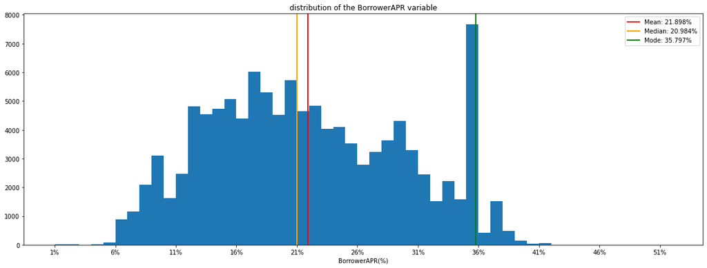

## Zoom in the peak around 35%

> Zooming in the 35% to 36% range, is possible to see that the peak around 35% saw on the distribution in fact are the loans with a 35.797% rate, which also happens to be the mode of the whole series.

> The quantity of loans with this same rate (3,672 loans, or 3.22% of all loans) suggest that this is a standard rate.

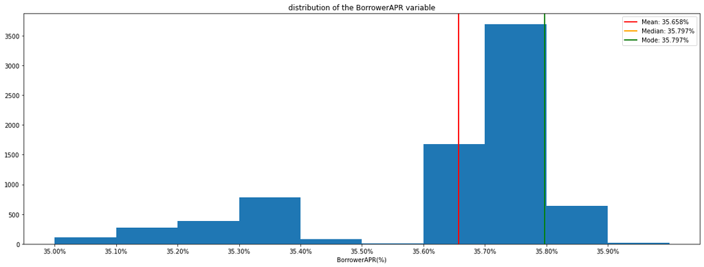

## Distribution of StatedMonthlyIncome

The distribution for the "StatedMonthlyIncome" has a large tail to the right, suggesting strong outliers to the right.

In fact, the range for this variable goes from 0 to 1.750 k USD, while the 99.9% percentile is only 44 k USD.

The distribution, even limited by the 99.9% percentile, is highly skewed to the right.

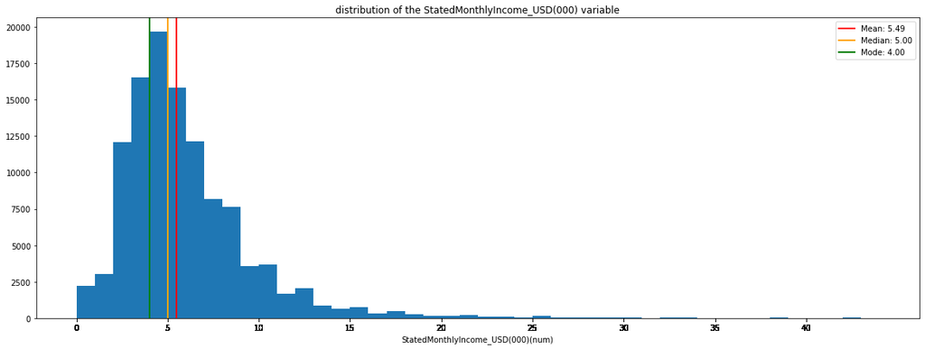

## BorrowerAPR vs Monthly Income When The Income Is Verifiable

Despite the very low correlation between StatedMonthlyIncome and BorrowerAPR (-0.16 and -0.06 for verifiable and not verifiable income, respectvely), it is possible to see that a higher income, when verifiable, tends to decrease the APR faster than when not verifiable.

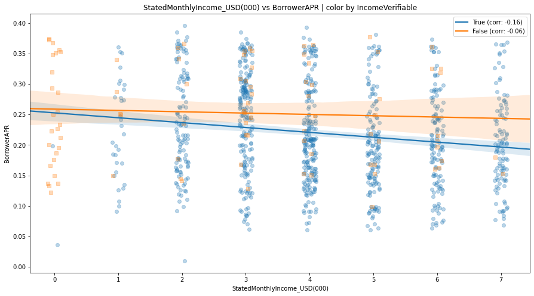